# HIPS: High Intensity Phenotyping Sites

Repository for the HIPS project collaboration between the Schnable lab at Iowa State University and the Schnable and Santra labs at the University of Nebraska-Lincoln. Contains trait data and associated metadata for 122 maize hybrids across 16 location years (defined as a unique combination of location, year, and irrigation level) in Iowa and Nebraska between 2022 and 2024. 9 of the location years also have 368 inbred lines from the maize SAM panel. In 11 of the hybrid location years, there were 2-3 levels of nitrogen fertilizer applied to different blocks of the field. In 4 of the inbred location years, there were 3 levels of nitrogen fertilizer applied to different blocks of the field. All other location years had one level of nitrogen fertilizer applied to the entire field. ## Overview of Experimental Design

### 2022 hybrids

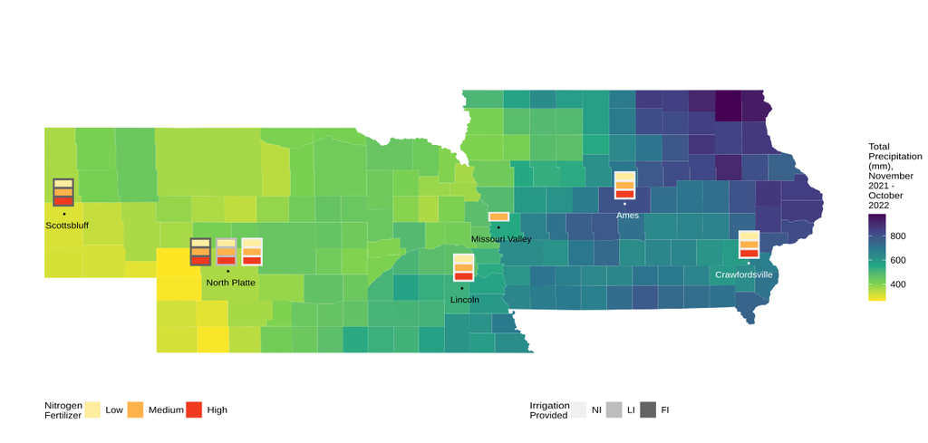

### 2022 inbreds

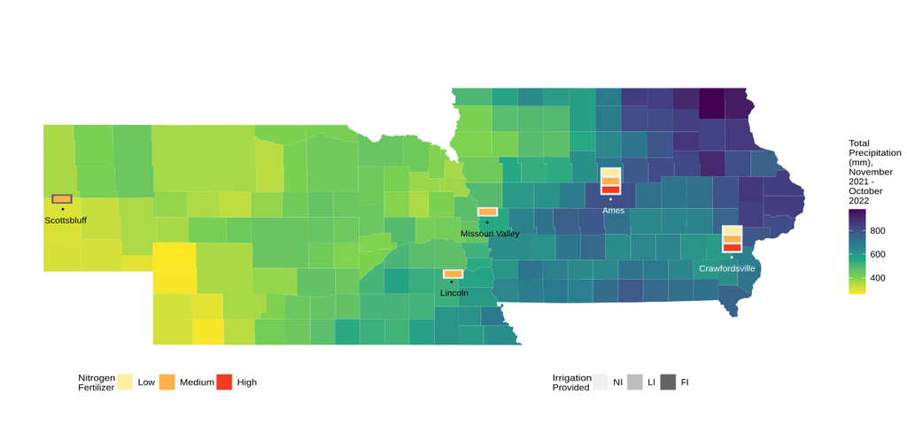

### 2023 hybrids

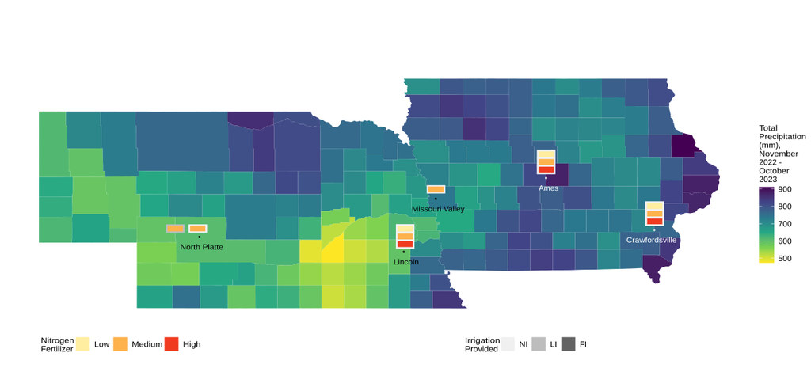

### 2023 inbreds

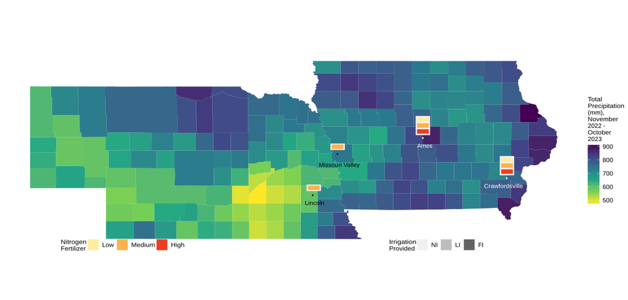

### 2024 hybrids

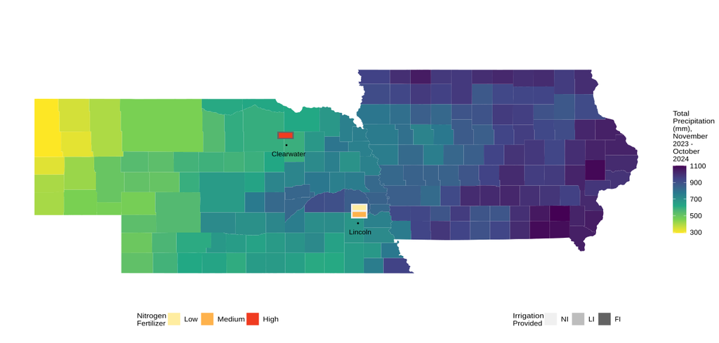

## Citation

If you use the hybrid data in your work, please cite the following paper:

Davis, J.M., Coffey, L.M., Turkus, J., López-Corona, L., Linders, K., Ullagaddi, C., Santra, D.K., Schnable, P.S. and Schnable, J.C. (2025), Assessing the Impact of Yield Plasticity on Hybrid Performance in Maize. Physiologia Plantarum, 177: e70278. https://doi.org/10.1111/ppl.70278

Bibtex:

[output not shown]

Please contact schnable@unl.edu if you wish to use the inbred data in your work.